# Prediction of frogs species arround the water reservoirs in Poland

Source: https://archive.ics.uci.edu/ml/datasets/Amphibians

Goal is to prepare predictive analysis of the occurance of few amphibians species from several attributes. Since there is 7 types of species, where they are not mutually exclusive (each row in the dataset can have more than 1 target) we are delaing with so-called multi-label classification and therefore my approach would be to developed one binary classifier per each of the target.

If the targets would be mutually exclusive - every row has one assigned target - we would be dealing with multi-class problem, that can be solved within one predictive model with usage of categorical crossentropy loss.

## Distribution of targets

```
Green frogs
0.5714285714285714
```

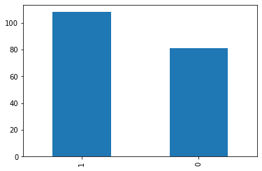

```
---------------------------------------------
Brown frogs
0.783068783068783
```

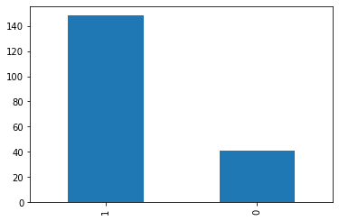

```
---------------------------------------------
Common toad
0.656084656084656
```

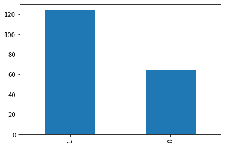

```
---------------------------------------------
Fire-bellied toad
0.30687830687830686
```

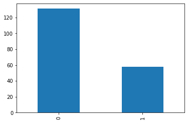

```
---------------------------------------------
Tree frog
0.37566137566137564
```

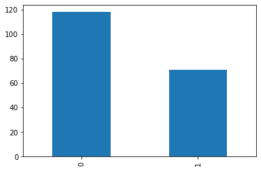

```
---------------------------------------------
Common newt
0.30687830687830686
```

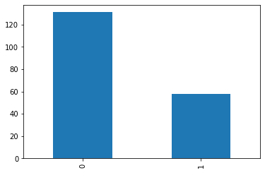

```
---------------------------------------------
Great crested newt
0.1111111111111111
```

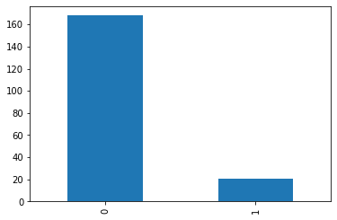

## Plot correlation matrix of targets

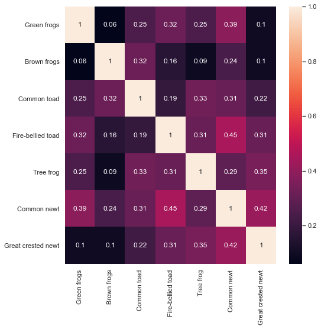

# EDA of categorical variables

```
TR
```

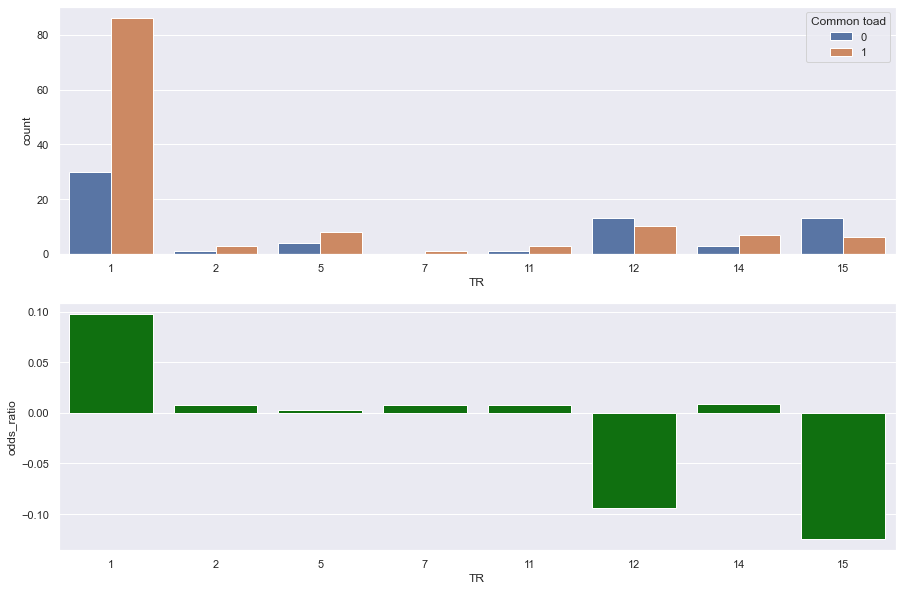

```
--------------------------------------------------------------------------------------------------------------
--------------------------------------------------------------------------------------------------------------
VR
```

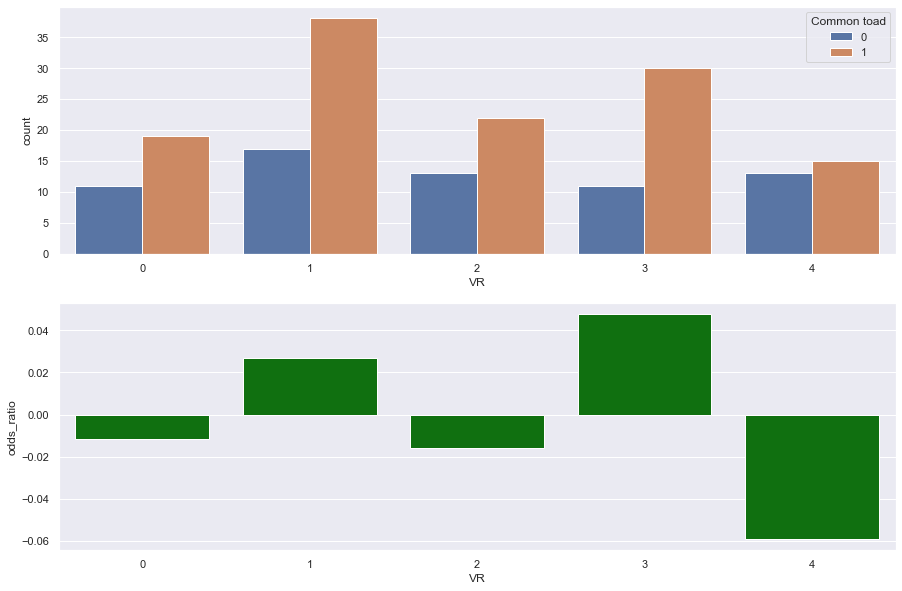

```
--------------------------------------------------------------------------------------------------------------
--------------------------------------------------------------------------------------------------------------
SUR1
```

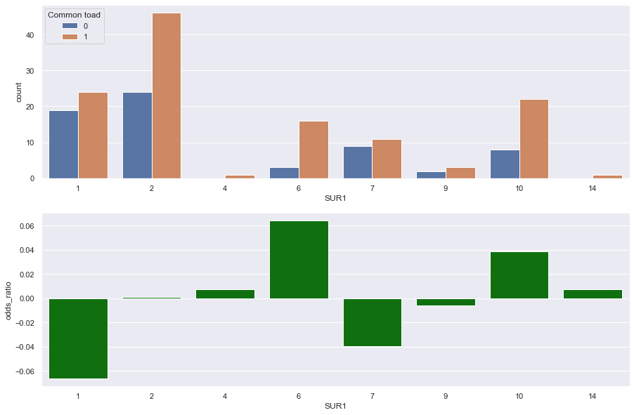

```
--------------------------------------------------------------------------------------------------------------
--------------------------------------------------------------------------------------------------------------
SUR2
```

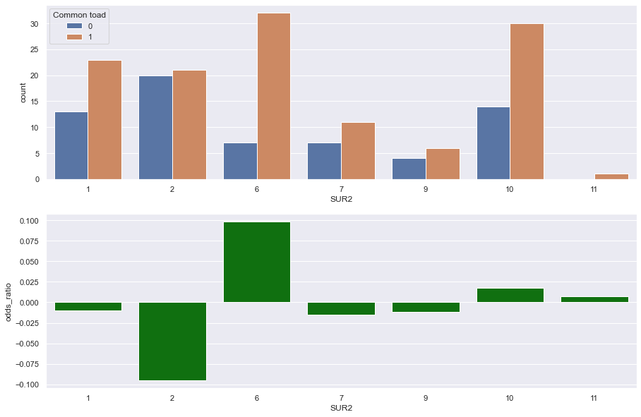

```
--------------------------------------------------------------------------------------------------------------
--------------------------------------------------------------------------------------------------------------
SUR3
```

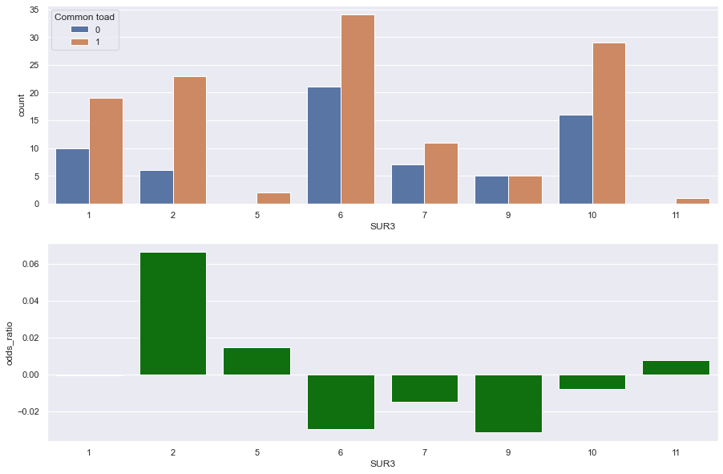

```
--------------------------------------------------------------------------------------------------------------
--------------------------------------------------------------------------------------------------------------
UR
```

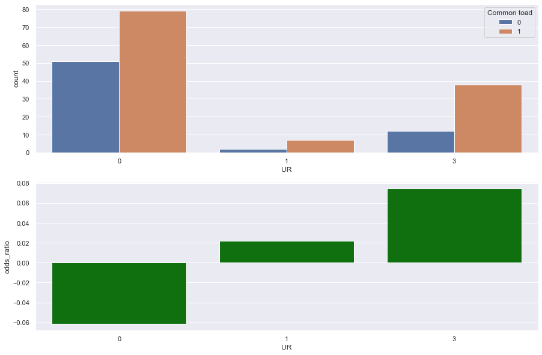

```
--------------------------------------------------------------------------------------------------------------
--------------------------------------------------------------------------------------------------------------
FR
```

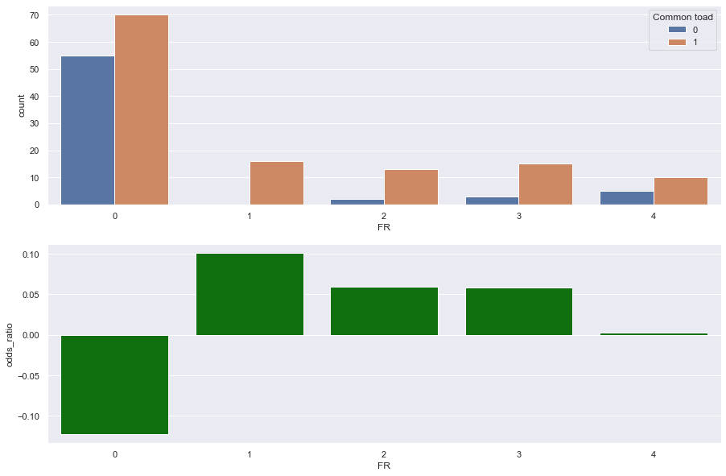

```
--------------------------------------------------------------------------------------------------------------
--------------------------------------------------------------------------------------------------------------
OR
```

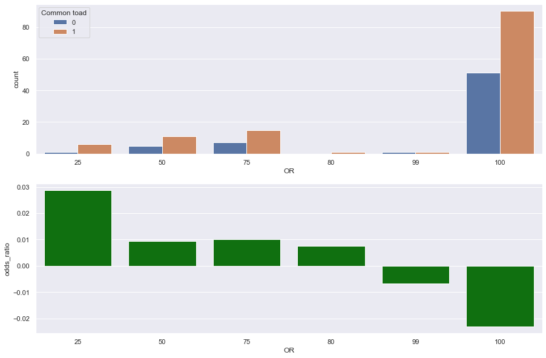

```
--------------------------------------------------------------------------------------------------------------
--------------------------------------------------------------------------------------------------------------
MR
```

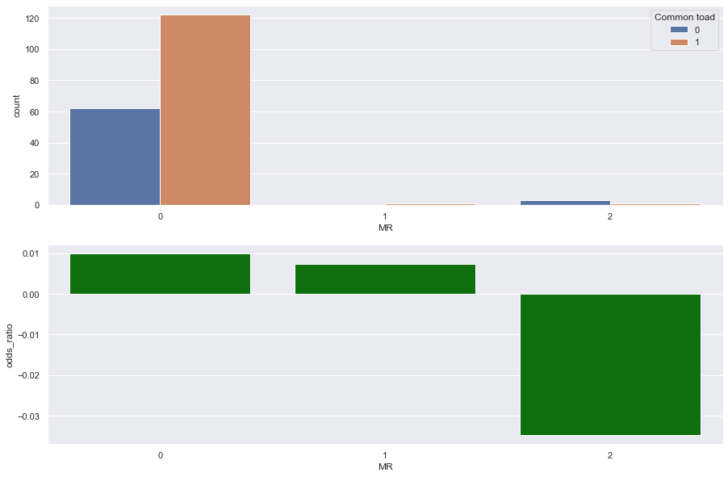

```
--------------------------------------------------------------------------------------------------------------
--------------------------------------------------------------------------------------------------------------
CR
```

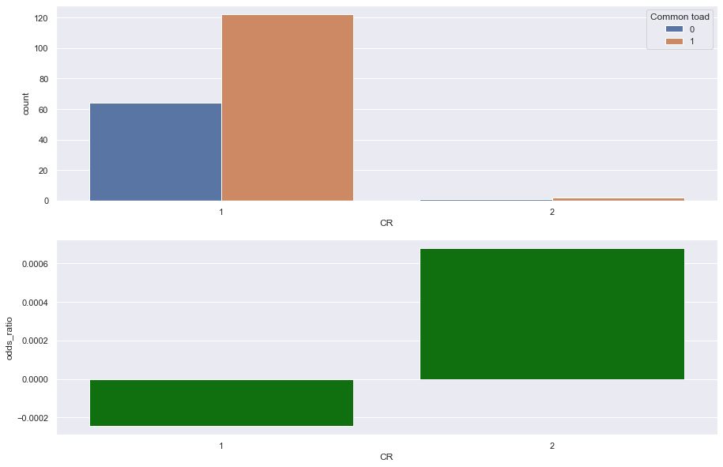

# Explanatory data analysis of numerical variables

```
SR
SAME FREQUENCY BINNING:
```

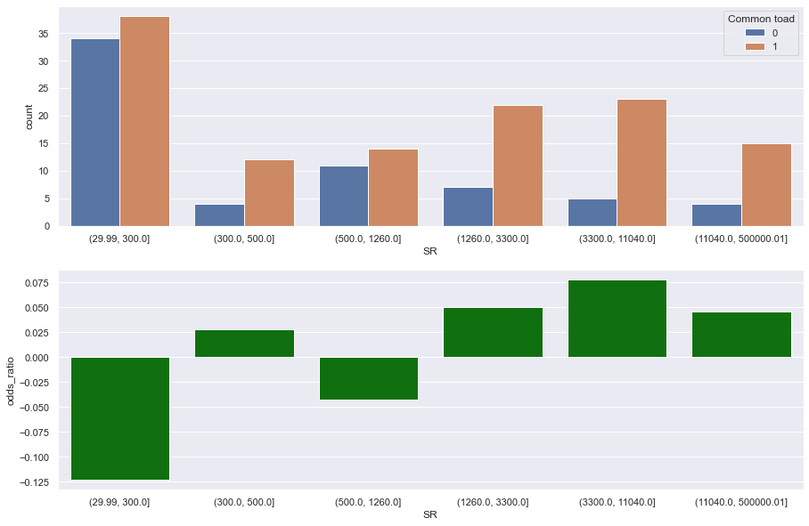

```
AUC of this variable:
0.619
---------------------------------------------------------
---------------------------------------------------------
NR
SAME FREQUENCY BINNING:
```

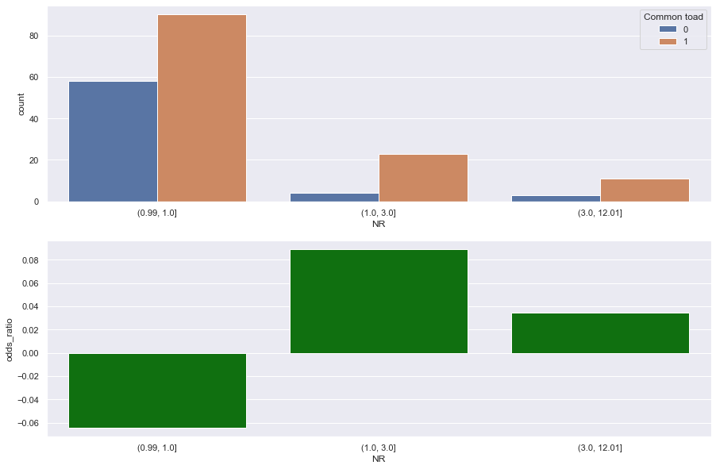

```
AUC of this variable:
0.583
---------------------------------------------------------
---------------------------------------------------------
RR
SAME FREQUENCY BINNING:
```

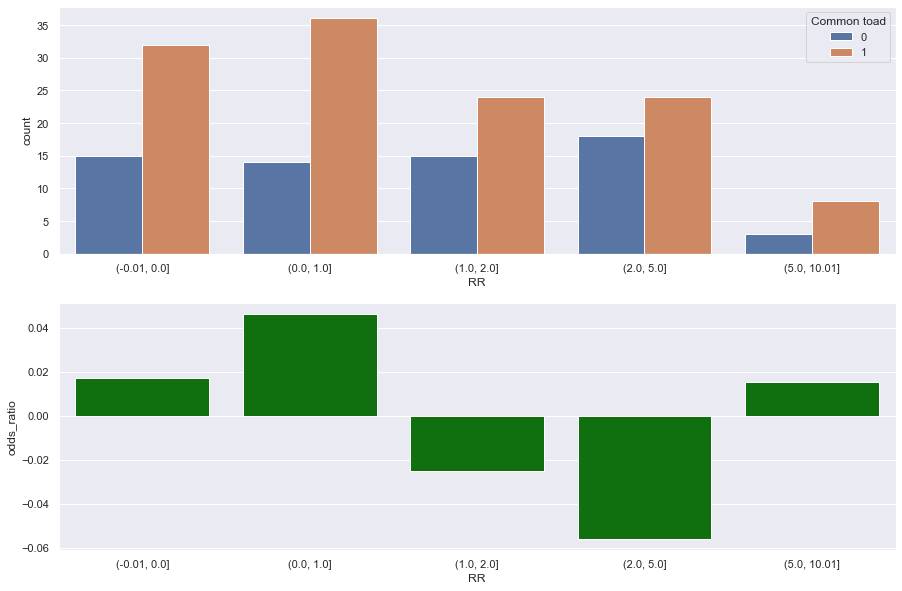

```
AUC of this variable:
0.542
---------------------------------------------------------
---------------------------------------------------------
BR
SAME FREQUENCY BINNING:
```

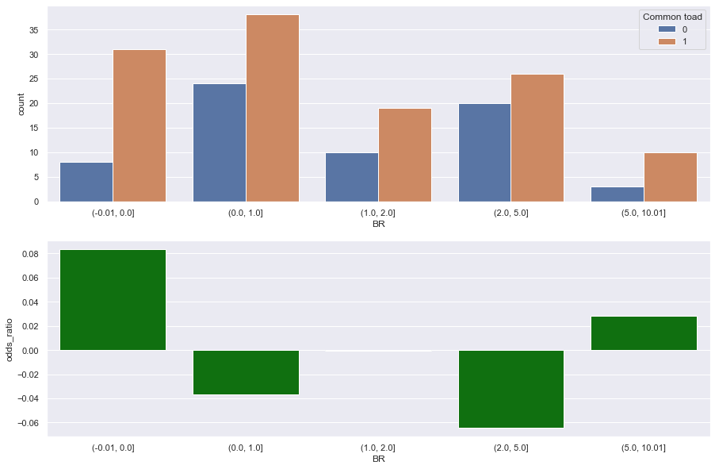

```
AUC of this variable:
0.556
---------------------------------------------------------
---------------------------------------------------------
```

## Findings from EDA of numerical variables:

- Attributes SR and NR looks quite promissing with same relationship to the target variable (The higher value of variable, the higher chance to target 1 (occurence of frog)). And it makes sense, because these variables means surface of water reservoirs and number of water reservoirs.
- Attribute BR (distance to buildings) looks useless (but only for this types of frogs. It could be different for other types)

## Introduction of predictive models - LGBM, Random Forest, Decision Tree

LGBM is newer implementation of famous XGBoost algorithm. Trained model is ensemble of many decision trees (usually), where every next decision tree is trained with (pseudo)residuals as a target variable from previous decion trees. Final prediction is then made as average of these decision trees.

LGBM implementation has few advantages over XGBoost - it can handle categorical variables implicitly (you do not need OHE), training of the model is much faster, etc. The results are usually pretty similar.

Fitting of decision trees requires less data preparation than for example logistic regression, where linear relationship between target and variables is demanded. For example I do not have to care about quadratic relationship between age and target, because decision trees can handle it pretty fine. Therefore I do not need to care much about data preprocessing right now (i am not saying, that is never necessary). Next big advantage of decion trees is that in a similar way as nonlinearity implicitely finds interactions between variables. In the linear models you will never find interactions, unless you will create them manually.

Disadvantage of these algorithms is that they are often harder to explain then linear models, where the whole model can be written as equation.

Random forest is in the same ensemble of independently constructed decision trees. Final prediction is consequently made as average from particular trees.

I will use implementation from sci-kit learn library. Unfortunatelly, RF can't handle categorical features implicitely (LGBM does), so I have to use one hot encoding transformation.

## Modelling strategy:

Since the data are unusually small (only 190 rows), we have to select proper training strategy, that I will try to describe now:

1. Strictly split the data to train and test in ratio 70-30. These 30 percents of completely unseen data will be used for results comparison.
2. Take the training data and perform 4-fold stratified cross-validation. Use validation set as the set for finetunning of parameters - number of trees in lgbm and random forest, depth size in case of decision tree. This will result fo have 4 predictive models - one model per fold.
3. Take the unseen test data and score it with each of your 4 models. Take the average prediction as the final one.
4. Repeat this approach for all 3 classifiers and compare performances on the same test set.
5. Repeat it for all frog species.

## Results - AUC performances

```python
df
```

|  | labels | AUC_lgbm | AUC_RF | AUC_DT |
| --- | --- | --- | --- | --- |
| 0 | Green frogs | 0.747537 | 0.722906 | 0.711823 |
| 1 | Brown frogs | 0.612957 | 0.553156 | 0.456811 |
| 2 | Common toad | 0.653226 | 0.740695 | 0.654467 |
| 3 | Fire-bellied toad | 0.685216 | 0.657807 | 0.710963 |
| 4 | Tree frog | 0.581618 | 0.645588 | 0.638971 |
| 5 | Common newt | 0.651709 | 0.632479 | 0.642450 |
| 6 | Great crested newt | 0.755714 | 0.585714 | 0.605714 |

# Variable importance

There is a lot ways how to measure the importance of predictors. One of the approach is to use so-called importance gain of tree models. Since we have 7 targets (species of frogs) and each model is constructed as ensemble of 4 models from cross-validation, total average will be used.

Other methods are for example: Shap values - this would be the most appropriate one, unfortunatelly it is not that easy to calculate for this average of ensembles, marginacl contribution of predictor to model's performance, importance weight, information value of predictor.

Variable importance is shown only for lgbm models.

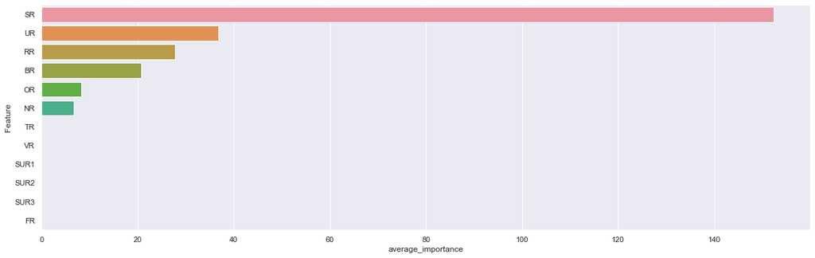

# Conclusion

I can see gaps for improvement of this solution/results in more proper fine-tunning of hyperparameters of given model. But unfortunatelly, there would be still problem even with optimized parameters to validation data, that validation data are really small and model will be overfitted to this set. Other method that probably could be helpful for this task with small dataset is to try standard logistic regression with weight of evidence encoding of variables. This method does not overfitts usually as much as tree methods does. Unfortunatelly, because of more difficult preparation of features, this method was ommited because of lack of time.

Regarding variable importance, it looks that most used predictor in lgbm models is 'SR' - Surface of water reservoir, following by UR - Use of water reservoirs and RR - Minimum distance from the water reservoir to roads. On the other hand, it looks like that lgbm does not use some of the predictors at all - i.e. SUR1,2,3 that denotes surrounding. On the other hand these predictors could be used, in random forest or in decision tree.